# Hack The Feed: Insights From Social Media Data

## by Iyanujesu Akinyefa

# Shaping the Digital Horizon: Stanbic IBTC's Social Media Analysis

## Introduction:

Digital interactions are the pulse of today's businesses. Through a meticulous examination of Stanbic IBTC's social media data, we've unearthed pivotal insights that can guide future engagement strategies.

### Data Preliminaries:

- Scope: Extensive data from platforms including Facebook, Instagram, LinkedIn, and Twitter.
- Integrity: Rigorous data cleaning ensured trustworthy analyses.
- Key Metrics: Engagement metrics such as likes, shares, comments, and reactions formed the crux of our exploration.

### Key Insights: Preferred Content Types

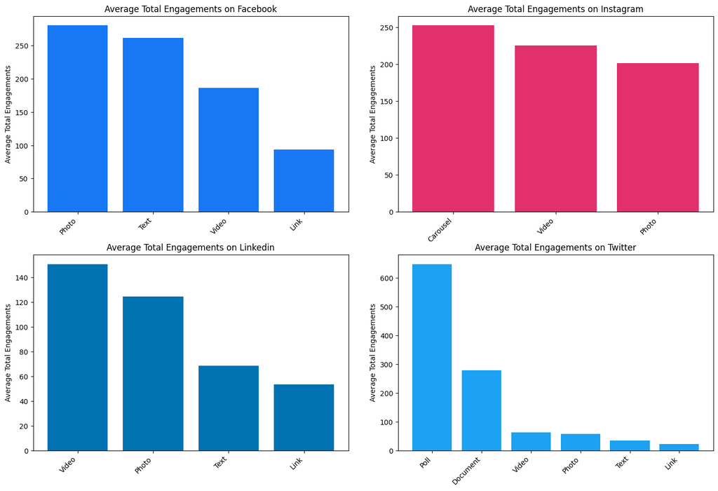

### Key Insights - Platform Analysis

- Instagram stands out as the platform with the highest overall engagement.
- Facebook and LinkedIn shows high reach but lower interaction.
- Twitter show consistent engagement.

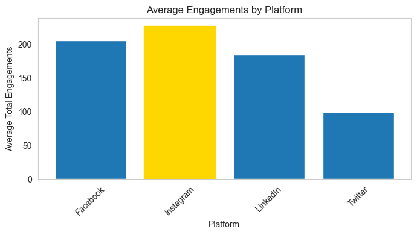

### Key Insights - Time-based Analysis

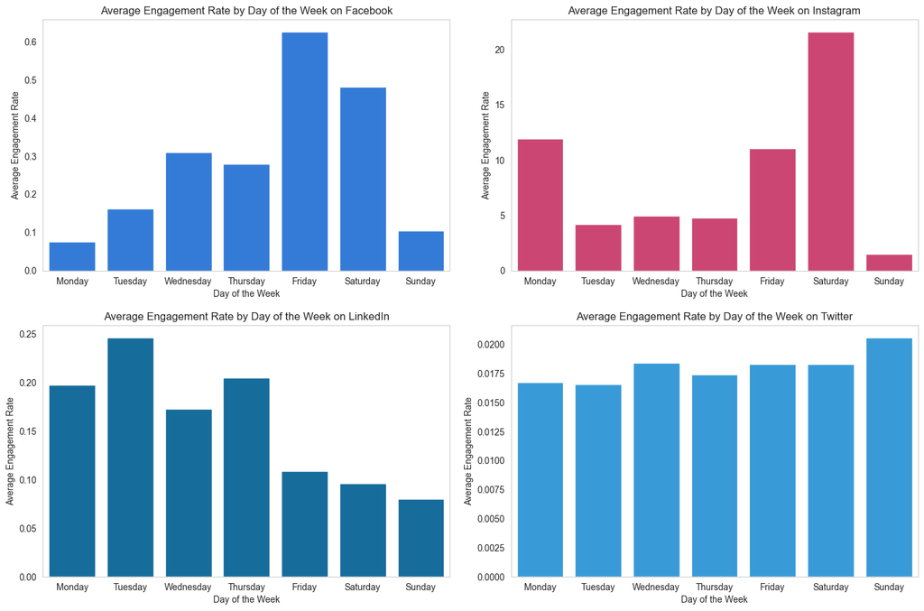

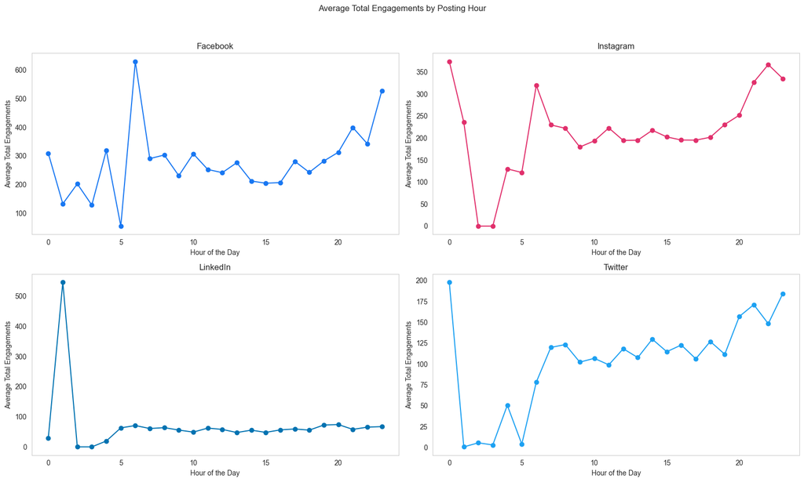

### Key Insights - Textual Analysis

- Campaign Chronicles: Hashtags like #ITCANBE suggest flagship campaigns or initiatives by Stanbic IBTC. Their frequent appearance underscores their significance in the bank's digital narrative.
- Engagement Enhancers: Certain hashtags might correlate with higher engagements, indicating their resonance with the audience.
- Collaborative Canvas: Mentions of certain entities or influencers, such as @stanbicibtc, highlight collaborations, partnerships, or affiliations.
- Engagement Echoes: Similar to hashtags, frequent mentions might be associated with posts that have higher visibility or engagement.

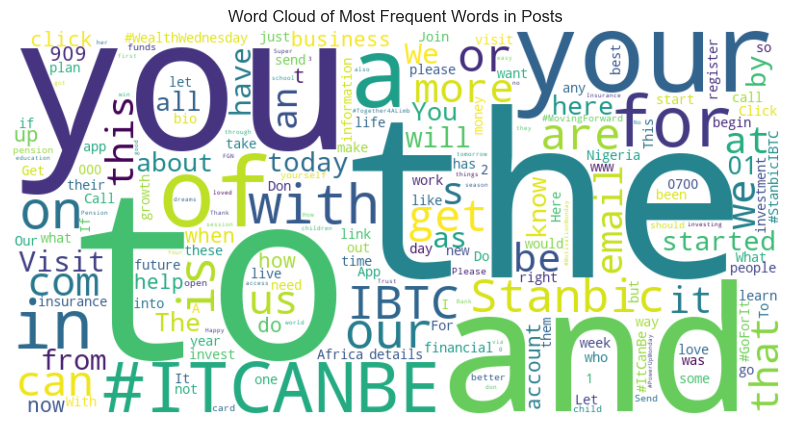

### Advanced Analysis

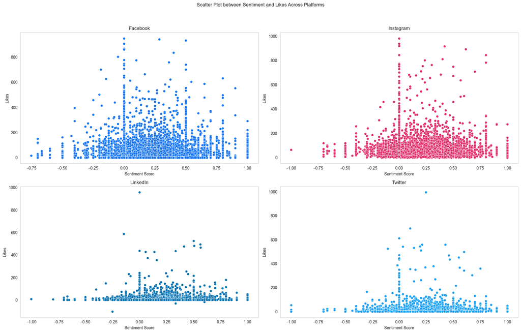

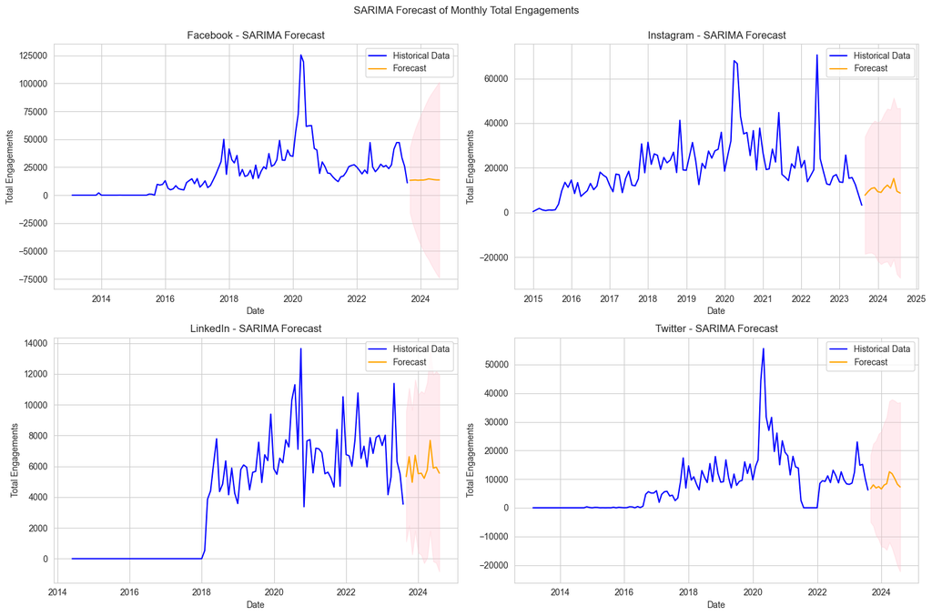

#### Regression Analysis Findings

Our regression models were aimed at predicting future engagement trends. The models, trained on historical data, provided insights into potential future patterns of user interactions.

#### Significance in Forecasting:

With predictive analytics, Stanbic IBTC can proactively tailor its digital strategy. It helps in anticipating user behavior, optimizing resource allocation, and ensuring that content and campaigns are aligned with future trends.

### Key Insights

- Instagram as the Engagement Powerhouse:

Stanbic IBTC's presence on Instagram has proven to be significantly impactful. With the highest number of likes and comments across all platforms, it's clear that the audience on Instagram is highly engaged and responsive.

- Unique Content Preferences:

- Positive Sentiment Around Certain Posts:

Sentiment analysis revealed that certain posts garnered overwhelmingly positive feedback from the audience. Such posts can serve as benchmarks for future content strategies.

### Recommendations

- Diversified Content Strategy:

To cater to diverse platform preferences, it's crucial to have a mix of content types – images, videos, infographics, and more. This ensures that content resonates with the unique audience of each platform.

- Engagement-Driven Scheduling:

Post content during peak engagement times to maximize visibility and interaction. Utilize scheduling tools to automate this process and maintain consistency.

- Introducing Feedback Mechanisms:

Allow users to provide feedback on content and campaigns. This can be done through polls, surveys, or direct feedback channels. It ensures that the audience feels valued and provides valuable insights for improvement.

- Rolling Out Periodic Webinars or Training Sessions:

Engage the audience with informative sessions about banking, financial planning, or other relevant topics. It not only positions Stanbic IBTC as an industry expert but also drives engagement and trust.

### Conclusion

#### Importance of Analysis:

In today's digital era, understanding user behavior on social media is paramount. This analysis provided a deep dive into Stanbic IBTC's digital footprint, revealing patterns, preferences, and opportunities.

#### Actionable Insights:

The derived insights, ranging from peak engagement times to content preferences, provide a roadmap for refining the digital strategy. These insights are not just observations but actionable pointers that can drive decision-making.

#### Potential Impact on Stanbic IBTC's Digital Strategy:

Implementing the recommendations and insights from this analysis can significantly enhance Stanbic IBTC's digital outreach, engagement rates, and overall brand perception. It sets the stage for a more informed, data-driven, and effective digital strategy.